# Datos limpios

Alicia Mastretta-Yanes

27 de abril de 2016

Los **datos limpios** son datos que facilitan las tareas del análisis de datos:

- **Manipulación**: Manipulación de variables como agregar, filtrar, reordenar, transformar.
- **Visualización**: Resúmenes de datos usando gráficas, análisis exploratorio, o presentación de resultados.
- **Modelación**: Ajustar modelos es sencillo si los datos están en la forma correcta.

Los principios de **datos limpios** ([Tidy Data de Hadley Wickham](http://vita.had.co.nz/papers/tidy-data.pdf)) proveen una manera estándar de organizar la información:

1. Cada variable forma una columna.
2. Cada observación forma un renglón.
3. Cada tipo de unidad observacional forma una tabla.

Veamos un ejemplo:

La mayor parte de las bases de datos en estadística tienen forma rectangular, ¿cuántas variables tiene la siguiente tabla?

|  | tratamientoA | tratamientoB |
| --- | --- | --- |
| Juan Aguirre | - | 2 |
| Ana Bernal | 16 | 11 |
| José López | 3 | 1 |

La tabla anterior también se puede estructurar de la siguiente manera:

|  | Juan Aguirre | Ana Bernal | José López |
| --- | --- | --- | --- |
| tratamientoA | - | 16 | 3 |
| tratamientoB | 2 | 11 | 1 |

Si vemos los principios (cada variable forma una columna, cada observación forma un renglón, cada tipo de unidad observacional forma una tabla), ¿las tablas anteriores cumplen los principios?

Para responder la pregunta veamos primero cuáles son las variables y cuáles las observaciones de esta pequeña base. Las variables son: persona/nombre, tratamiento y resultado. Entonces, siguiendo los principios de *datos limpios* obtenemos la siguiente estructura:

| nombre | tratamiento | resultado |
| --- | --- | --- |
| Juan Aguirre | a | - |
| Ana Bernal | a | 16 |
| José López | a | 3 |
| Juan Aguirre | b | 2 |
| Ana Bernal | b | 11 |
| José López | b | 1 |

Una vez que identificamos los problemas de una base de datos podemos proceder a la limpieza.

### Limpieza de bases de datos

Algunos de los problemas más comunes en las bases de datos que no están *limpias* son:

- Los encabezados de las columnas son valores y no nombres de variables.
- Más de una variable por columna.
- Las variables están organizadas tanto en filas como en columnas.
- Más de un tipo de observación en una tabla.
- Una misma unidad observacional está almacenada en múltiples tablas.

La mayor parte de estos problemas se pueden arreglar con pocas herramientas, a continuación veremos como *limpiar* datos usando dos funciones del paquete *tidyr*:

- **gather**: recibe múltiples columnas y las junta en pares de nombres y valores, convierte los datos anchos en largos.
- **spread**: recibe 2 columnas y las separa, haciendo los datos más anchos.

Para otras funciones parecidas no se pierdan este acordeón:

[R Data Wrangling Cheat Sheet](https://www.rstudio.com/wp-content/uploads/2015/02/data-wrangling-cheatsheet.pdf)

#### Los encabezados de las columanas son valores

Usaremos ejemplos para entender los conceptos más facilmente. La primer base de datos está basada en una encuesta de [Pew Research](http://www.pewforum.org/2009/01/30/income-distribution-within-us-religious-groups/) que investiga la relación entre ingreso y afiliación religiosa.

¿Cuáles son las variables en estos datos?

```r
# leemos la base
pew <- read.delim(file = "http://stat405.had.co.nz/data/pew.txt",
  header = TRUE, stringsAsFactors = FALSE, check.names = F)
pew
```

```
##                   religion <$10k $10-20k $20-30k $30-40k $40-50k $50-75k
## 1                 Agnostic    27      34      60      81      76     137
## 2                  Atheist    12      27      37      52      35      70
## 3                 Buddhist    27      21      30      34      33      58
## 4                 Catholic   418     617     732     670     638    1116
## 5       Don’t know/refused    15      14      15      11      10      35
## 6         Evangelical Prot   575     869    1064     982     881    1486
## 7                    Hindu     1       9       7       9      11      34
## 8  Historically Black Prot   228     244     236     238     197     223
## 9        Jehovah's Witness    20      27      24      24      21      30
## 10                  Jewish    19      19      25      25      30      95
## 11           Mainline Prot   289     495     619     655     651    1107
## 12                  Mormon    29      40      48      51      56     112
## 13                  Muslim     6       7       9      10       9      23
## 14                Orthodox    13      17      23      32      32      47
```

[output cut: 23 more lines]

Esta base de datos tiene 3 variables: religión, ingreso y frecuencia. Para *limpiarla* es necesario apilar las columnas (alargar los datos). Notemos que al alargar los datos desapareceran las columnas que se agrupan y dan lugar a dos nuveas columnas: la correspondiente a clave y la correspondiente a valor. Entonces, para alargar una base de datos usamos la función `gather` que recibe los argumentos:

- data: base de datos que vamos a reestructurar.
- key: nombre de la nueva variable que contiene lo que fueron los nombres de columnas que apilamos.
- value: nombre de la variable que almacenará los valores que corresponden a cada *key*.
- …: lo último que especificamos son las columnas que vamos a apilar, veremos que hay varias maneras de determinarlas.

```r
# cargamos el paquete
library(tidyr)
library(plyr)
library(dplyr)
pew_tidy <- gather(data = pew, income, frequency, -religion)
# vemos las primeras líneas de nuestros datos alargados
head(pew_tidy)
```

```
##             religion income frequency
## 1           Agnostic  <$10k        27
## 2            Atheist  <$10k        12
## 3           Buddhist  <$10k        27
## 4           Catholic  <$10k       418
## 5 Don’t know/refused  <$10k        15
## 6   Evangelical Prot  <$10k       575
```

```r
# y las últimas
tail(pew_tidy)
```

```
##                  religion             income frequency
## 175                Muslim Don't know/refused        22
## 176              Orthodox Don't know/refused        73
## 177       Other Christian Don't know/refused        18
## 178          Other Faiths Don't know/refused        71
## 179 Other World Religions Don't know/refused         8
## 180          Unaffiliated Don't know/refused       597
```

Observemos que en la tabla ancha teníamos bajo la columna *<$10k*, en el renglón correspondiente a *Agnostic* un valor de 27, y podemos ver que este valor en la tabla larga se almacena bajo la columna frecuencia y corresponde a religión *Agnostic*, income *<$10k*. También es importante ver que en este ejemplo especificamos las columnas a apilar identificando la que **no** vamos a alargar con un signo negativo: es decir apila todas las columnas menos religión.

La nueva estructura de la base de datos nos permite, por ejemplo, hacer fácilmente una gráfica donde podemos comparar las diferencias en las frecuencias (veremos como graficar la siguiente clase, los ejemplos de abajo son solo para que veamos lo que se puede hacer).

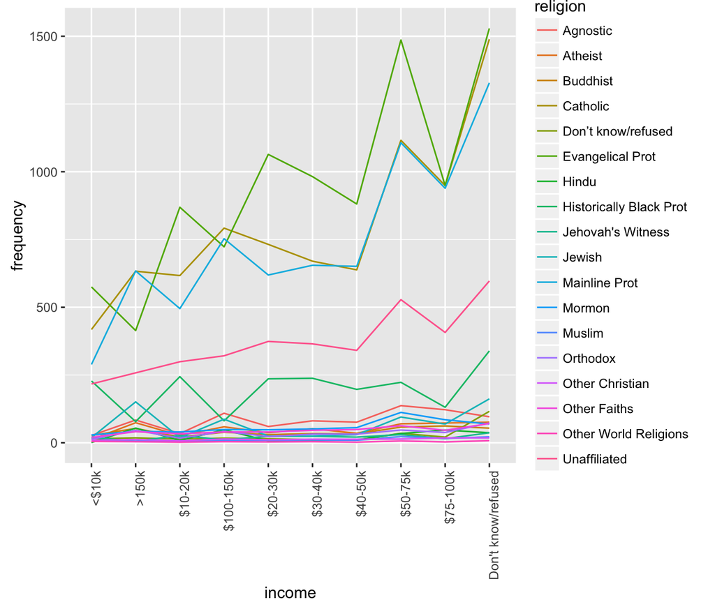

```r
library(ggplot2)
ggplot(pew_tidy, aes(x = income, y = frequency, color = religion,
  group = religion)) +
  geom_line() +
  theme(axis.text.x = element_text(angle = 90, hjust = 1))
```

Podemos hacer gráficas más interesantes si creamos nuevas variables:

```r
by_religion <- group_by(pew_tidy, religion)
pew_tidy_2 <- pew_tidy %>%
  filter(income != "Don't know/refused") %>%
  group_by(religion) %>%
  mutate(percent = frequency / sum(frequency)) %>%
  filter(sum(frequency) > 1000)

head(pew_tidy_2)
```

```
## Source: local data frame [6 x 4]
## Groups: religion [5]
##
##                  religion  income frequency    percent
##                     (chr)   (chr)     (int)      (dbl)
## 1                Catholic   <$10k       418 0.06367098
## 2        Evangelical Prot   <$10k       575 0.07239078
## 3 Historically Black Prot   <$10k       228 0.13768116
## 4           Mainline Prot   <$10k       289 0.04705308
## 5            Unaffiliated   <$10k       217 0.06977492
## 6                Catholic $10-20k       617 0.09398324
```

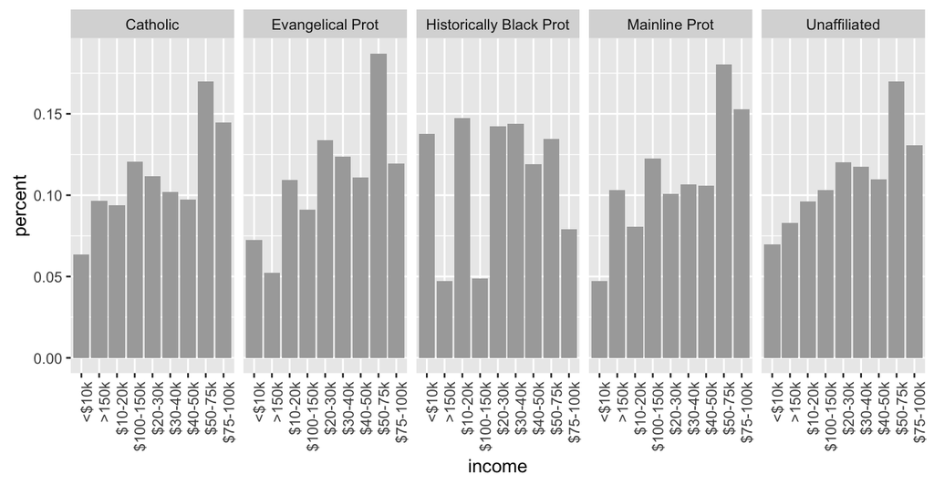

```r
ggplot(pew_tidy_2, aes(x = income, y = percent, group = religion)) +
  facet_wrap(~ religion, nrow = 1) +
  geom_bar(stat = "identity", fill = "darkgray") +
  theme(axis.text.x = element_text(angle = 90, hjust = 1))
```

#### Una columna asociada a más de una variable

La siguiente base de datos proviene de la Organización Mundial de la Salud y contiene el número de casos confirmados de tuberculosis por país y año, la información esta por grupo demográfico de acuerdo a sexo (m, f), y edad (0-4, 5-14, etc).

```r
tb <- read.csv("../Practicas/Uni7/data/tb.csv")
head(tb)
```

```
##   id iso2 year new_sp_m04 new_sp_m514 new_sp_m014 new_sp_m1524
## 1  1   AD 1989         NA          NA          NA           NA
## 2  2   AD 1990         NA          NA          NA           NA
## 3  3   AD 1991         NA          NA          NA           NA
## 4  4   AD 1992         NA          NA          NA           NA
## 5  5   AD 1993         NA          NA          NA           NA
## 6  6   AD 1994         NA          NA          NA           NA
##   new_sp_m2534 new_sp_m3544 new_sp_m4554 new_sp_m5564 new_sp_m65 new_sp_mu
## 1           NA           NA           NA           NA         NA        NA
## 2           NA           NA           NA           NA         NA        NA
## 3           NA           NA           NA           NA         NA        NA
## 4           NA           NA           NA           NA         NA        NA
## 5           NA           NA           NA           NA         NA        NA
## 6           NA           NA           NA           NA         NA        NA
##   new_sp_f04 new_sp_f514 new_sp_f014 new_sp_f1524 new_sp_f2534
## 1         NA          NA          NA           NA           NA
## 2         NA          NA          NA           NA           NA
## 3         NA          NA          NA           NA           NA
## 4         NA          NA          NA           NA           NA
## 5         NA          NA          NA           NA           NA
## 6         NA          NA          NA           NA           NA
##   new_sp_f3544 new_sp_f4554 new_sp_f5564 new_sp_f65 new_sp_fu
## 1           NA           NA           NA         NA        NA
## 2           NA           NA           NA         NA        NA
## 3           NA           NA           NA         NA        NA
## 4           NA           NA           NA         NA        NA
## 5           NA           NA           NA         NA        NA
## 6           NA           NA           NA         NA        NA
```

```r
colnames(tb)
```

```
##  [1] "id"           "iso2"         "year"         "new_sp_m04"
##  [5] "new_sp_m514"  "new_sp_m014"  "new_sp_m1524" "new_sp_m2534"
##  [9] "new_sp_m3544" "new_sp_m4554" "new_sp_m5564" "new_sp_m65"
## [13] "new_sp_mu"    "new_sp_f04"   "new_sp_f514"  "new_sp_f014"
## [17] "new_sp_f1524" "new_sp_f2534" "new_sp_f3544" "new_sp_f4554"
## [21] "new_sp_f5564" "new_sp_f65"   "new_sp_fu"
```

**Ejercicio** De manera similar a los ejemplos anteriores, utiliza la función `gather` para apilar las columnas correspondientes a sexo-edad en una nueva columna llamada “demo” y otra columna llamada “n” que contenga el número de casos confirmados.

Ahora separaremos las variables sexo y edad de la columna demo, para ello debemos pasar a la función `separate`, esta recibe como parámetros:

- data: el nombre de la base de datos,
- col: el nombre de la variable que deseamos separar en más de una,
- into: nombre que queremos que tengan las nuevas columnas
- sep= la posición de donde deseamos “cortar” (hay más opciones para especificar como separar, ver `?separate`)

```r
tb_tidy <- separate(tb_long, demo, c("sex", "age"), 8)
head(tb_tidy)
```

```
##    id iso2 year      sex age n
## 16 16   AD 2005 new_sp_m  04 0
## 17 17   AD 2006 new_sp_m  04 0
## 19 19   AD 2008 new_sp_m  04 0
## 43 43   AE 2006 new_sp_m  04 0
## 44 44   AE 2007 new_sp_m  04 0
## 45 45   AE 2008 new_sp_m  04 0
```

```r
table(tb_tidy$sex)
```

```
##
## new_sp_f new_sp_m
##    17830    17920
```

Nota que en este caso utilizamos sep=8 porque la m y la f son el octavo caracter en “new_sp_m”

#### Variables almacenadas en filas y columnas

El problema más difícil es cuando las variables están tanto en filas como en columnas, veamos una base de datos de clima en Cuernavaca. ¿Cuáles son las variables en estos datos?

```r
clima <- read.delim("../Practicas/Uni7/data/clima.txt", stringsAsFactors=FALSE)
head(clima)
```

```
##            id year month element d1  d2  d3 d4  d5 d6 d7 d8 d9 d10 d11 d12
## 1 MX000017004 2010     1    TMAX NA  NA  NA NA  NA NA NA NA NA  NA  NA  NA
## 2 MX000017004 2010     1    TMIN NA  NA  NA NA  NA NA NA NA NA  NA  NA  NA
## 3 MX000017004 2010     2    TMAX NA 273 241 NA  NA NA NA NA NA  NA 297  NA
## 4 MX000017004 2010     2    TMIN NA 144 144 NA  NA NA NA NA NA  NA 134  NA
## 5 MX000017004 2010     3    TMAX NA  NA  NA NA 321 NA NA NA NA 345  NA  NA
## 6 MX000017004 2010     3    TMIN NA  NA  NA NA 142 NA NA NA NA 168  NA  NA
##   d13 d14 d15 d16 d17 d18 d19 d20 d21 d22 d23 d24 d25 d26 d27 d28 d29 d30
## 1  NA  NA  NA  NA  NA  NA  NA  NA  NA  NA  NA  NA  NA  NA  NA  NA  NA 278
## 2  NA  NA  NA  NA  NA  NA  NA  NA  NA  NA  NA  NA  NA  NA  NA  NA  NA 145
## 3  NA  NA  NA  NA  NA  NA  NA  NA  NA  NA 299  NA  NA  NA  NA  NA  NA  NA
## 4  NA  NA  NA  NA  NA  NA  NA  NA  NA  NA 107  NA  NA  NA  NA  NA  NA  NA
## 5  NA  NA  NA 311  NA  NA  NA  NA  NA  NA  NA  NA  NA  NA  NA  NA  NA  NA
## 6  NA  NA  NA 176  NA  NA  NA  NA  NA  NA  NA  NA  NA  NA  NA  NA  NA  NA
##   d31
## 1  NA
## 2  NA
## 3  NA
## 4  NA
## 5  NA
## 6  NA
```

Estos datos tienen variables en columnas individuales (id, año, mes), en múltiples columnas (día, d1-d31) y en filas (tmin, tmax). Comencemos por apilar las columnas con `gather`.

```r
clima_long <- gather(clima, day, value, d1:d31, na.rm = TRUE)
head(clima_long)
```

```
##             id year month element day value
## 21 MX000017004 2010    12    TMAX  d1   299
## 22 MX000017004 2010    12    TMIN  d1   138
## 25 MX000017004 2010     2    TMAX  d2   273
## 26 MX000017004 2010     2    TMIN  d2   144
## 41 MX000017004 2010    11    TMAX  d2   313
## 42 MX000017004 2010    11    TMIN  d2   163
```

Ahora creemos algunas variables adicionales.

```r
clima_vars <- clima_long %>%
  mutate(day = extract_numeric(day), value = value / 10)  %>%
  select(id, year, month, day, element, value) %>%
  arrange(id, year, month, day)
head(clima_vars)
```

```
##            id year month day element value
## 1 MX000017004 2010     1  30    TMAX  27.8
## 2 MX000017004 2010     1  30    TMIN  14.5
## 3 MX000017004 2010     2   2    TMAX  27.3
## 4 MX000017004 2010     2   2    TMIN  14.4
## 5 MX000017004 2010     2   3    TMAX  24.1
## 6 MX000017004 2010     2   3    TMIN  14.4
```

**Pregunta:** ¿Qué hacen las funciones `mutate` y `select`?

Finalmente, la columna *element* no es una variable, sino que almacena el nombre de dos variables (Tmax y Tmin), la operación que debemos aplicar es`spread`, que es el inverso de `gather`:

```r
clima_tidy <- spread(clima_vars, element, value)
head(clima_tidy)
```

```
##            id year month day TMAX TMIN
## 1 MX000017004 2010     1  30 27.8 14.5
## 2 MX000017004 2010     2   2 27.3 14.4
## 3 MX000017004 2010     2   3 24.1 14.4
## 4 MX000017004 2010     2  11 29.7 13.4
## 5 MX000017004 2010     2  23 29.9 10.7
## 6 MX000017004 2010     3   5 32.1 14.2
```

#### Otras consideraciones

En las buenas prácticas es importante tomar en cuenta los siguientes puntos:

- Incluir un encabezado con el nombre de las variables.
- Los nombres de las variables deben ser entendibles (e.g. TejidoMuestra es mejor que TeM).
- En general los datos se deben guardar en un archivo por tabla.
- Escribir un script con las modificaciones que se hicieron a los *datos crudos* (reproducibilidad).
- Otros aspectos importantes en la *limpieza* de datos son: selección del tipo de variables (por ejemplo fechas), datos faltantes, *typos* (e.g. *Phhaseoulus*) y detección de valores atípicos (temp= 240 °C en vez de 24.0)